# Simulação de Dados Dendrométricos

Simulação de Dados Dendrométricos (Khaya Ivorensis - Mogno Africano) Deivison Venicio Souza

Universidade Federal do Pará - UFPA

🌳🌳🌳🌳🌳🌳  
deivisonvs@ufpa.br  
https://github.com/DeivisonSouza

1ª versão: 10/Abril/2022  
(Atualizado em: 14/abril/2022)

# 1 Informações gerais para simulação

## 1.1 Objetivos

- Simular dados para as variáveis diâmetro a 1,30m do solo ($d$) e altura ($h$) para a espécie 🌳*Khaya Ivorensis*🌳.
- Calcular o volume das árvores usando a fórmula $v_i = \dfrac{(\pi d^2)}{40000}(h)(0,7)$.

## 1.2 Características admitidas para simulação

Com objetivo de simular dados condizentes aos encontrados na natureza será admitido que:

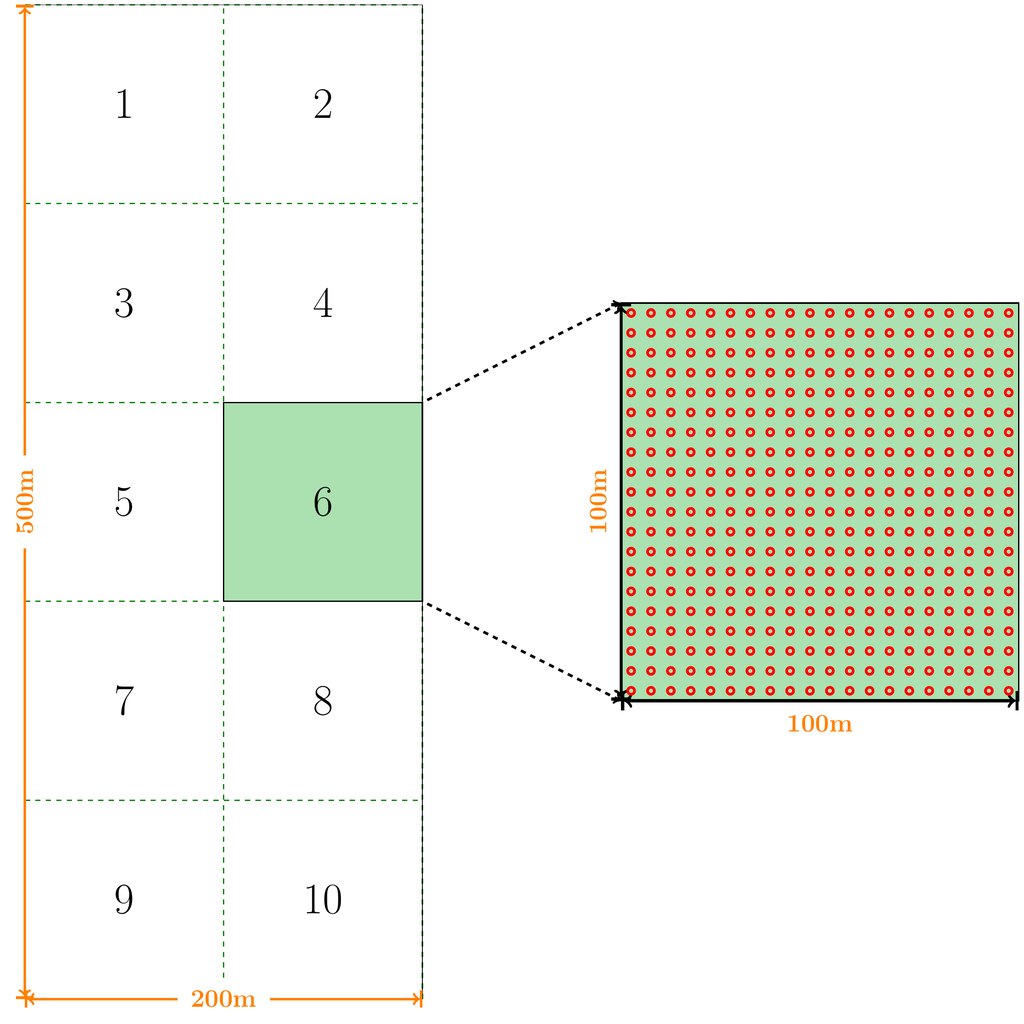

# 2 Simulação de dados dendrométricos

- Serão simulados dados de $d$ (cm) e $h$ (m) para as 10 parcelas possíveis de 1 hectare (400 árvores/parcela).
- Os dados serão simulados a partir da distribuição normal, variando a média e desvio padrão por parcela.
- A função `runif()` será usada para gerar dados aleatórios da distribuição uniforme para os valores de média e desvio padrão usados na `rnorm()`.
- A função `rnorm()` foi usada para gerar dados aleatórios da distribuição normal. Esta possui 3 parâmetros: **n** = número de observações; **mean** = vetor de médias; e **sd** = vetor de desvio padrão.

```r
## Carrega pacotes

library(purrr)
library(tidyr)
library(dplyr)
```

```r
## Gera valores aleatórios de médias e desvio padrão para uso na rnorm()
## Para cada parcela será usada uma média e um desvio padrão diferente

set.seed(10)
df <- data.frame(
  mean_d = runif(n = 10, min = 25, max = 27),
  sd_d = runif(n = 10, min = 1, max = 2),
  mean_h = runif(n = 10, min = 9, max = 10),
  sd_h = runif(n = 10, min = .5, max = 1)
) %>%
  mutate(across(everything(), round, 2))

  knitr::kable(df)
```

| mean_d | sd_d | mean_h | sd_h |
| --- | --- | --- | --- |
| 26.01 | 1.65 | 9.86 | 0.77 |
| 25.61 | 1.57 | 9.62 | 0.55 |
| 25.85 | 1.11 | 9.78 | 0.58 |
| 26.39 | 1.60 | 9.36 | 0.95 |
| 25.17 | 1.36 | 9.41 | 0.71 |
| 25.45 | 1.43 | 9.71 | 0.87 |
| 25.55 | 1.05 | 9.84 | 0.91 |
| 25.54 | 1.26 | 9.24 | 0.98 |
| 26.23 | 1.40 | 9.77 | 0.84 |
| 25.86 | 1.84 | 9.36 | 0.75 |

```r
## Simula dados normais para diâmetro p/ cada parcela

arv_parc <- 1:400  # número de observações/parcela (árvores/parcela)
n <- 10            # número de parcelas

set.seed(100)
simul_d <- map_dfr(arv_parc, ~ setNames(rnorm(n, mean = df$mean_d, sd = df$sd_d),
                                        stringr::str_c("P", 1:10))) %>%
  pivot_longer(everything(), names_to = "Parc", values_to = "d") %>%
  mutate(across(where(is_character), forcats::as_factor)) %>%
  mutate(across(where(is_double), round, 2)) %>%
  arrange(Parc, desc(d))
```

```r
## Simula dados normais para altura p/ cada parcela

set.seed(100)
simul_h <- map_dfr(arv_parc, ~ setNames(rnorm(n, mean = df$mean_h, sd = df$sd_h),
                                        stringr::str_c("P", 1:10))) %>%
  pivot_longer(everything(), names_to = "Parc", values_to = "h") %>%
  mutate(across(where(is_character), forcats::as_factor)) %>%
  mutate(across(where(is_double), round, 1)) %>%
  arrange(Parc, desc(h))
```

```r
## Combina data.frames e calcula volume

data <- bind_cols(simul_d, simul_h[c("h")]) %>%
  mutate(v = ((pi*(d^2))/40000)*h*0.7) %>%
  mutate(across(c(v), round, 4))

# writexl::write_xlsx(data, 'data/Khaya-simulado.xlsx')
```

```r
## Visualiza as 2 primeiras linhas de cada parcela

data %>%
  group_by(Parc) %>%
  top_n(n = 2) %>%
  knitr::kable()
```

[output not shown]

```r
## Calcula média, desvio e total do volume por Parcela

data %>%
  group_by(Parc) %>%
  summarise(across(#.cols = where(is.numeric),
                   .cols = v,
                   .fns = list(media=mean, desv=sd, soma=sum),
                   na.rm = TRUE,
                   .names = "{.col}.{.fn}"
  )
  ) %>%
  knitr::kable()
```

| Parc | v.media | v.desv | v.soma |
| --- | --- | --- | --- |
| P1 | 0.3706925 | 0.0761411 | 148.2770 |
| P2 | 0.3539250 | 0.0656689 | 141.5700 |
| P3 | 0.3631830 | 0.0503256 | 145.2732 |
| P4 | 0.3629817 | 0.0851519 | 145.1927 |
| P5 | 0.3292880 | 0.0610615 | 131.7152 |
| P6 | 0.3512310 | 0.0755966 | 140.4924 |
| P7 | 0.3576338 | 0.0611954 | 143.0535 |
| P8 | 0.3352352 | 0.0666380 | 134.0941 |
| P9 | 0.3769272 | 0.0708400 | 150.7709 |
| P10 | 0.3461675 | 0.0751899 | 138.4670 |

**Consideração Final**

- Simulamos dados para uma população florestal de 🌳*Khaya Ivorensis*🌳 (10 hectares) com 4000 árvores, admitindo que 10 parcelas de 1ha são possíveis de serem instaladas na população. **Portanto, via simulação temos os dados populacionais!**.
- Porém, na prática, em **inventários florestais**, comumente os dados dendrométricos são medidos em **parcelas amostrais sob algum processo de amostragem** e, em seguida, a variável de interesse é extrapolada para a população (inferência).
- Portanto, na sequência, vamos admitir esses dados para simular o uso da amostragem aleatória simples. Ou seja, vamos admitir que apenas **dados de algumas parcelas amostrais estarão disponíveis!**